# Nursery School Dataset

Nursery Database was derived from a hierarchical decision model originally developed to rank applications for nursery schools. It was used during several years in 1980's when there was excessive enrollment to these schools in Ljubljana, Slovenia, and the rejected applications frequently needed an objective explanation. The final decision depended on three subproblems: occupation of parents and child's nursery, family structure and financial standing, and social and health picture of the family. The model was developed within expert system shell for decision making DEX

Now We will read the data and load it into a dataframe in python.

```python
# Importing the libraries which we need now.


import pandas

from pandas.plotting import scatter_matrix

import matplotlib.pyplot as plt

%matplotlib inline

# Dataset from - https://archive.ics.uci.edu/ml/datasets/Nursery

df = pandas.read_table('nursery.txt', sep=',', header=None, names=['parents', 'has_nurs', 'form', 'children','housing',
                                                                   'finance','social','health','class'])
```

# Summarizing the Dataset

### 1. Dimensions Of the DataSet.

We have some data and if we don't know how many features and instances our dataset has, it is of no use. So, we should find the dimensions of the dataset.

```python
# shape attribute gives the dimensions of a dataframe

print df.shape
```

```
(12960, 9)
```

The above displayed result shows that the dataframe has 12960 rows and 9 colums. It means that we have 9 features and 12960 instances.

### 2. Looking at the data

It's a very good practice to look at your data before you proceed. We can look how our data is structured

```python
# Output printing out first 5 columns

df.head()
```

|  | parents | has_nurs | form | children | housing | finance | social | health | class |
| --- | --- | --- | --- | --- | --- | --- | --- | --- | --- |
| 0 | usual | proper | complete | 1 | convenient | convenient | nonprob | recommended | recommend |
| 1 | usual | proper | complete | 1 | convenient | convenient | nonprob | priority | priority |
| 2 | usual | proper | complete | 1 | convenient | convenient | nonprob | not_recom | not_recom |
| 3 | usual | proper | complete | 1 | convenient | convenient | slightly_prob | recommended | recommend |
| 4 | usual | proper | complete | 1 | convenient | convenient | slightly_prob | priority | priority |

### 3. Summary of our data

```python
# The describe function prints the summary of the data

print(df.describe())
```

```
       parents   has_nurs      form children   housing finance   social  \
count    12960      12960     12960    12960     12960   12960    12960
unique       3          5         4        4         3       2        3
top      usual  very_crit  complete        3  critical  inconv  nonprob
freq      4320       2592      3240     3240      4320    6480     4320

           health      class
count       12960      12960
unique          3          5
top     not_recom  not_recom
freq         4320       4320
```

If we look at the above result clearly, we can infer the following. Let us take example of the feature 'parent'

count : 12960 (It gives the number of instances of that feature. Here all features have same count. So, we can infer that there are no missing values.)

unique : 3 (This number says that there 3 different categories of feature parent.)

top : usual (This gives the category which occured the highest number of times in a feature)

freq : 4320 (This gives the frequency of the top occurence category in that feature.)

### 4. Class distribution

We can find out how the data is distributed. Because sometimes we might get some data which may be skewed. This leads to unexpected behaviour of our prediction model.

```python
# The group by function summarizes a particular feature.

print(df.groupby('class').size())
```

```
class
not_recom     4320
priority      4266
recommend        2
spec_prior    4044
very_recom     328
dtype: int64
```

In the above summary data, we ca see that the values feature has 5 different observations. So, we should look at the data distribution of the expected output for every instance.

Here, as we can see, the recommended variable is very less. Almost negligible. very_recom variable is seen in 328 observations which is not too high but enough to train our machine.

The remaining three variables are almost equally distributed. So, we are good to go

## Data Vizualization

Now that we have a rough idea of our dataset, we can understand it much better by vizualising it. Data can be vizualised by either Univariate plots or Multivariate plots.

Univariate plots helps us in understanding a particular feature.

Where as Multivariate plots helps us in understanding the relationship between different features.

### 1. Univariate plots

Now we will start with univariate plots to understand each feature in our dataset. Run the cell below to get the same information.

To plot the data, we need Integer values because we cannot plot strings. So, we should convert all the variables into Integer values. So, we use the map function to do the task.

```python
# Converting the data into Integers to plot.

df['parents'] = df.parents.map({'usual':0, 'pretentious':1, 'great_pret':2 })
df['has_nurs'] = df.has_nurs.map({'proper':0, 'less_proper':1, 'improper':2 ,'critical':3,'very_crit':4})
df['form'] = df.form.map({'complete':0, 'completed':1, 'incomplete':2,'foster':3 })
df['children'] = df.children.map({'1':1, '2':2,'3':3,'more':4 })
df['housing'] = df.housing.map({'convenient':0, 'less_conv':1, 'critical':2 })
df['finance'] = df.finance.map({'convenient':0, 'inconv':1 })
df['social'] = df.social.map({'nonprob':0, 'slightly_prob':1, 'problematic':2 })
df['health'] = df.health.map({'recommended':0, 'priority':1, 'not_recom':2 })
df['class'] = df['class'].map({ 'recommend':0,'not_recom':1, 'very_recom':2,'priority':3,'spec_prior':4 })



# Prints first five values of the dataset
df.head()
```

|  | parents | has_nurs | form | children | housing | finance | social | health | class |
| --- | --- | --- | --- | --- | --- | --- | --- | --- | --- |
| 0 | 0 | 0 | 0 | 1 | 0 | 0 | 0 | 0 | 0 |
| 1 | 0 | 0 | 0 | 1 | 0 | 0 | 0 | 1 | 3 |
| 2 | 0 | 0 | 0 | 1 | 0 | 0 | 0 | 2 | 1 |
| 3 | 0 | 0 | 0 | 1 | 0 | 0 | 1 | 0 | 0 |
| 4 | 0 | 0 | 0 | 1 | 0 | 0 | 1 | 1 | 3 |

Here if we observe the above dataframe, we can see that all the data is converted into Integer values which is suitable for plotting in various graphs.

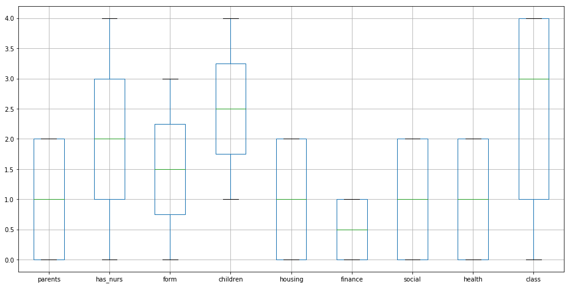

```python
# Sets the figure size

plt.rcParams['figure.figsize'] = (16,8)

# This plots the data in a box plot

df.boxplot()
```

The above figure shows the distribution of the data in a box plot.

[output not shown]

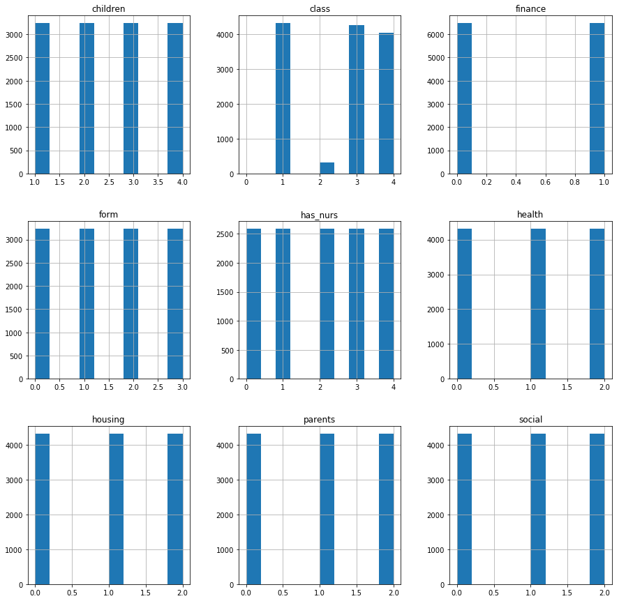

```python
# Sets the figure size

plt.rcParams['figure.figsize'] = (15,15)

# This plots the data in a histogram

df.hist()
```

The above figure shows the bar graph of all features.

### 2. Multivariate Plots

Now, we will create some multivariate plots.

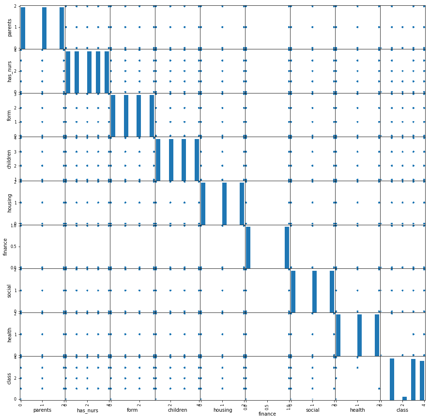

```python
# This piece of code generates a Matrix form of Scatter Plot.

scatter_matrix(df)

plt.rcParams['figure.figsize'] = (40, 40)

# Displays the scatter plot for our dataframe.

plt.show()
```

The above figure shows the scatter plots of all features in the form of a matrix.

## Summary

So, we described the feaures of Nursery School data, sanitized the data and vizualised it using pandas and matplotlib libraries.